# Lecture 11 - Probability part 5: more on expectation and variance

Joshua Loftus

January 31, 2018

#### Review

- Study guide, homework solutions
- Today: variance, Chebyshev’s inequality, random samples

##### Expected value of a function of random variable

- Suppose $X$ has distribution $p_X(x)$ with domain $D$ (the set of possible values), and $f$ is some function
- $f(X)$ is a new random variable. What is its expectation?
  $$E[f(X)] = \sum_{x \in D} f(x) p_X(x)$$
- e.g. variance calculation $f(x) = (x-\mu)^2$ (see Bernoulli example below)

##### Variance

- Measure of dispersion (spread) of a random variable
- Variance: $\text{Var}(X) = E[(X - \mu)^2]$
- Expected *squared distance* of $X$ from $\mu$
- e.g. For $X \sim$ Ber($p$), $\mu = p$, and $(X - p)^2$ is a random variable which equals $(1-p)^2$ with probability $p$ and equals $(0-p)^2$ with probability $1-p$. To find $\text{Var}(X)$ we compute the expected value of $(X-p)^2$, like this:
  $$\text{Var}(X) = (0-p)^2 \cdot (1-p) + (1-p)^2 \cdot p = [p^2 + (1-p)p](1-p) = p(1-p)$$
- Notation: sometimes use $\sigma^2$ for $\text{Var}(X)$ (if it’s clear from the context)
- Does this make sense as a measure of the dispersion of a Bernoulli?
- If $p = 1/2$, then $\sigma^2 = 1/4$. If $p = 9/10$, then $\sigma^2 = 9/100$ – $p$ close to 1 makes the Bernoulli more “concentrated,” it has less variance

###### Linearity

- If $X$ and $Y$ are **independent**, then $\text{Var}(X+Y) = \text{Var}(X) + \text{Var}(Y)$
- Unlike the case for expectation, where there was no requirement, we now need independence
- Without independence: there is a more complicated formula we won’t get into now
- Let’s look at some Binomial examples

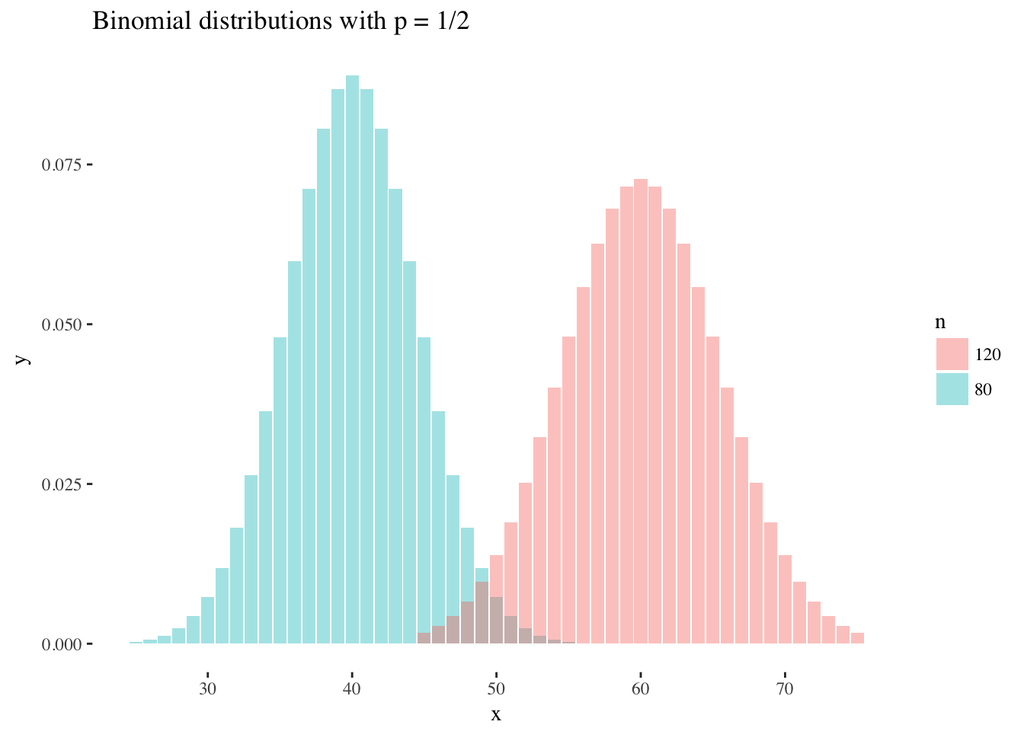

```r
df <- data.frame(x = c(25:55, 45:75),
                 y = c(dbinom(25:55, 80, .5), dbinom(45:75, 120, .5)),
                 n = c(rep("80", 31), rep("120", 31)))
ggplot(df, aes(x, y, fill = n)) +
  geom_bar(stat = "identity", position = "identity", alpha = .4) +
  theme_tufte() + ggtitle("Binomial distributions with p = 1/2")
```

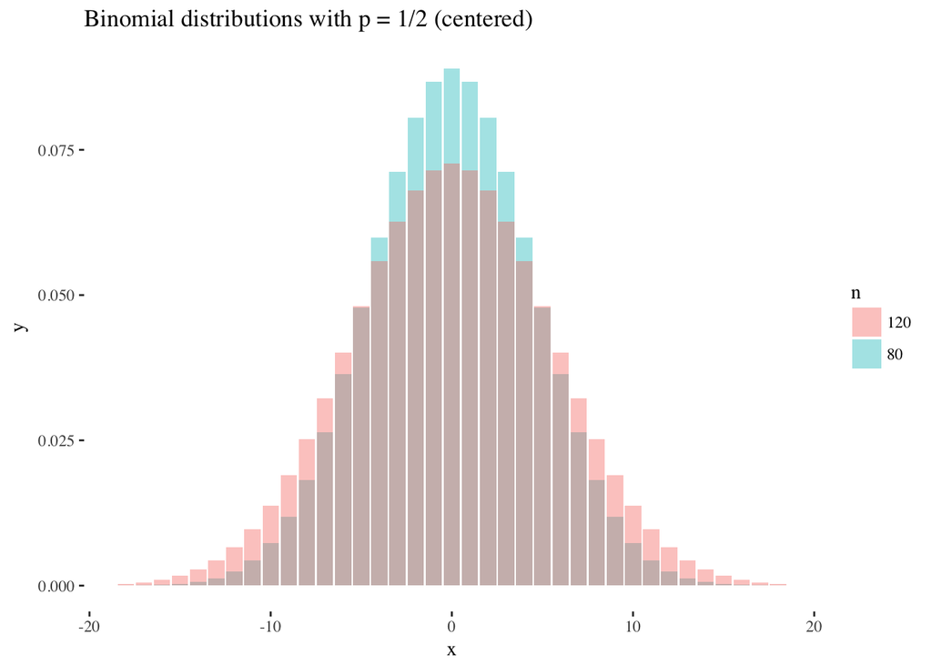

```r
df <- data.frame(x = c(-18:18, -18:18),
                 y = c(dbinom(22:58, 80, .5), dbinom(42:78, 120, .5)),
                 n = c(rep("80", 37), rep("120", 37)))
ggplot(df, aes(x, y, fill = n)) +
  geom_bar(stat = "identity", position = "identity", alpha = .4) +
  theme_tufte() + ggtitle("Binomial distributions with p = 1/2 (centered)")
```

- Looks like larger $n$ leads to larger variance

###### Chebyshev’s inequality

- Let $a > 0$ be any constant.
- Chebyshev’s inequality: $P(|X - \mu| \geq a) \leq \sigma^2/a^2$
- For example, let $a = 2\sigma$, then $P(|X - \mu| \geq 2\sigma) \leq 1/4$
- Look familiar? (We’ll come back to the 68-95-99 rule again soon)
- Helps justify use of expectation and variance as summaries of the full probability distribution

##### Samples of a random variable

- Suppose $X \sim$ Bin($n,p$), and we want to visualize the distribution function of $X$
- Since we know the formulas we could use those as before
- But if we can *generate* many observed values of $X$, we could also look at the histogram of those values. This will be a histogram of data rather than the “true” distribution function (much of statistics works by relating these two “worlds”)
- Remember the [Galton board](https://en.wikipedia.org/wiki/Galton_board)?

##### Examples from Bin(100, 1/2)

###### Perfect, symmetric, mathematical model world:

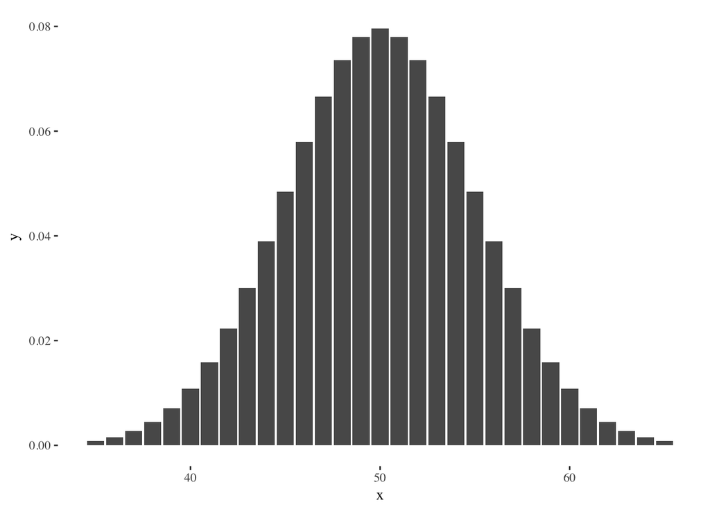

```r
df <- data.frame(x = 35:65, y = dbinom(35:65, 100, .5))
ggplot(df, aes(x, y)) + geom_bar(stat = "identity") + theme_tufte()
```

###### Noisy, messy, data world:

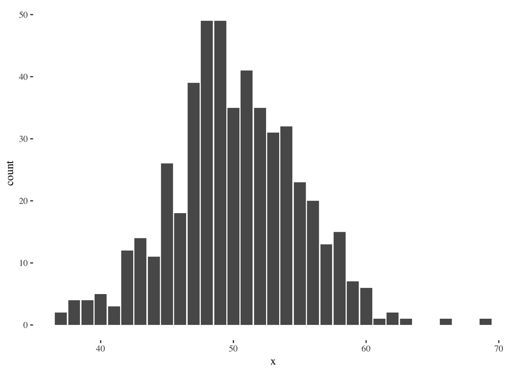

```r
df <- data.frame(x = rbinom(500, 100, .5))
ggplot(df, aes(x)) + stat_count() + theme_tufte()
```

###### Showing both together:

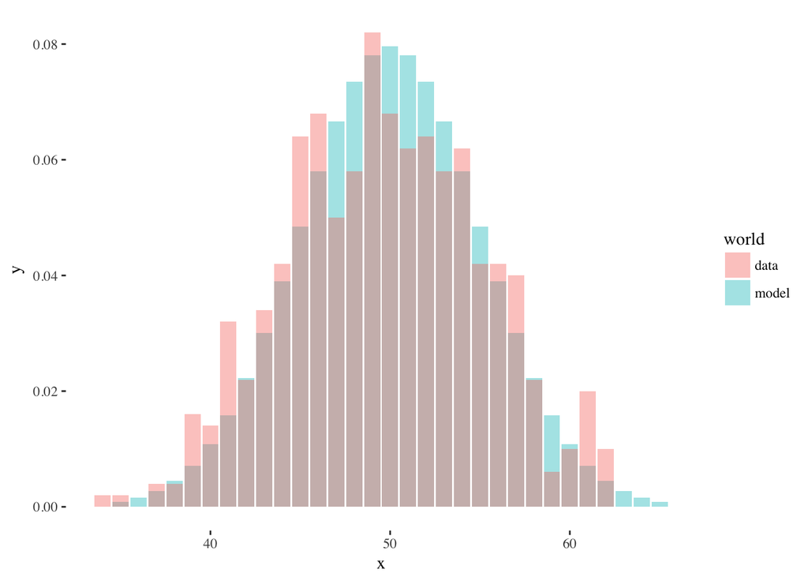

```r
sampledX <- table(rbinom(500, 100, .5))/500
nbins <- length(sampledX)
df <- data.frame(x = c(35:65, as.integer(names(sampledX))),
                 y = c(dbinom(35:65, 100, .5), sampledX),
                 world = c(rep("model", 31), rep("data", nbins)))
ggplot(df, aes(x, y, fill = world)) +
  geom_bar(stat = "identity", position = "identity", alpha = .4) + theme_tufte()
```

###### Increasing the sample size:

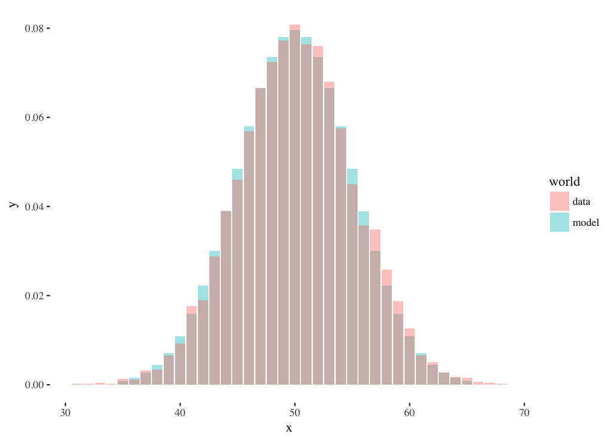

```r
sampledX <- table(rbinom(5000, 100, .5))/5000
nbins <- length(sampledX)
df <- data.frame(x = c(35:65, as.integer(names(sampledX))),
                 y = c(dbinom(35:65, 100, .5), sampledX),
                 world = c(rep("model", 31), rep("data", nbins)))
ggplot(df, aes(x, y, fill = world)) +
  geom_bar(stat = "identity", position = "identity", alpha = .4) + theme_tufte()
```

##### Breaking a key assumption of the Binomial: independence

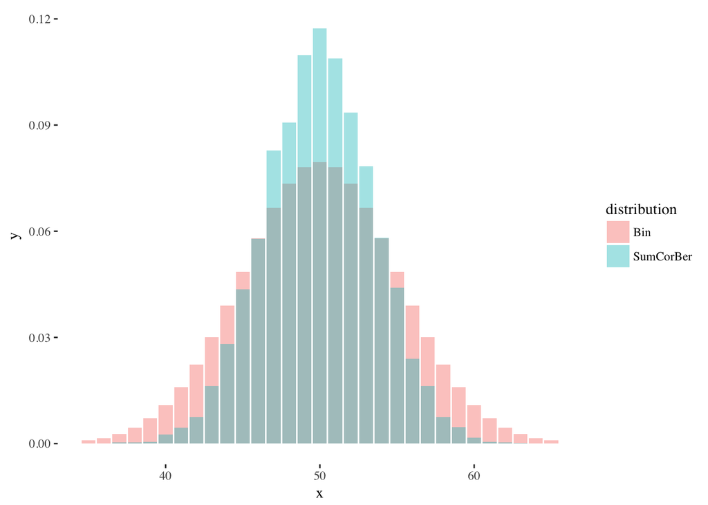

```r
X <- function(n) sum(sample(c(rep(0,n), rep(1,n)), n, replace = FALSE))
sampledX <- table(replicate(10000, X(100)))/10000
nbins <- length(sampledX)
df <- data.frame(x = c(35:65, as.integer(names(sampledX))),
                 y = c(dbinom(35:65, 100, .5), sampledX),
                 distribution = c(rep("Bin", 31), rep("SumCorBer", nbins)))
ggplot(df, aes(x, y, fill = distribution)) +
  geom_bar(stat = "identity", position = "identity", alpha = .4) + theme_tufte()
```

#### Examples from other distributions

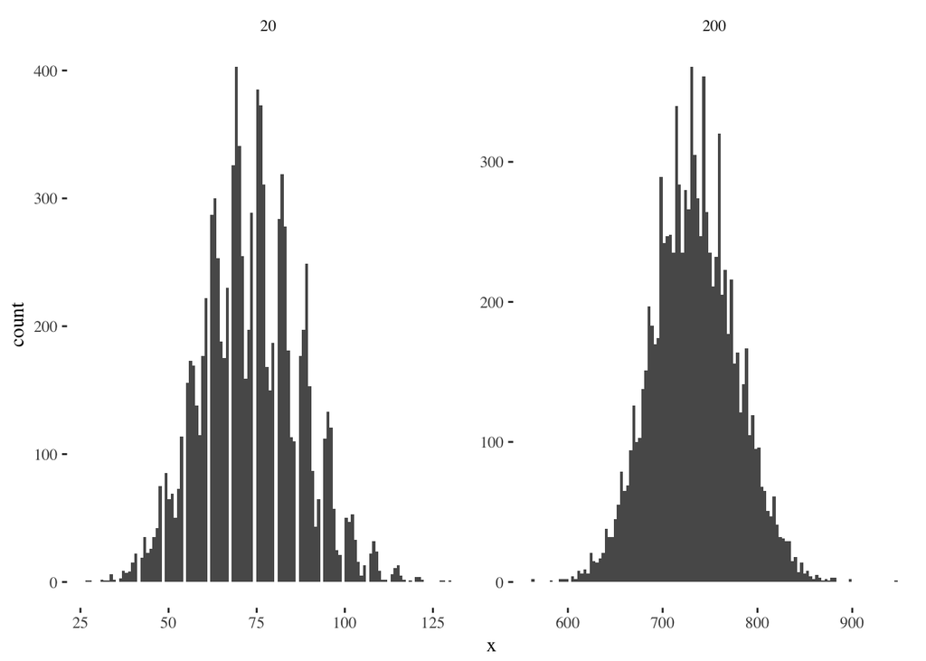

```r
X <- function(n) sum(sample(c(1,2,8), n, replace = TRUE))
df1 <- data.frame(x = c(replicate(10000, X(20)), replicate(10000, X(200))),
                  n = c(rep("20", 10000), rep("200", 10000)))
ggplot(df1, aes(x)) + geom_histogram(bins = 120) + facet_wrap(~n, scales = "free") + theme_tufte()
```